# statsass1

# Task 11

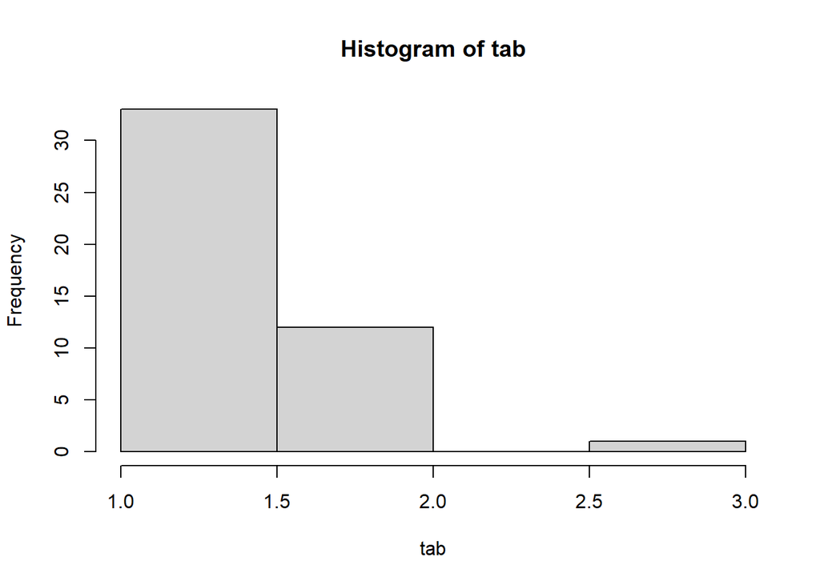

```r
volt <- read.csv("VOLTAGE.csv")
tab <- table(volt$ï..VOLTAGE)
hist(tab)
```

# Task 12

```r
pipe <- read.csv("ROUGHPIPE.csv")
y <- mean(pipe$ï..ROUGH)
s <- sd(pipe$ï..ROUGH)
s1 = y-2*s
s2 = y+2*s
s1
```

```
## [1] 0.8331772
```

```r
s2
```

```
## [1] 2.928823
```

Around 95% of all coated pipe roughness measurements are contained within (0.8331, 2.9288)

# Task 13

```r
gobi <- read.csv("GOBIANTS.csv")
head(gobi)
```

```
##   ï..Site      Region Rain Temp PlantCov AntSpecies Diversity
## 1       1  Dry Steppe  196  5.7       40          3      0.89
## 2       2  Dry Steppe  196  5.7       52          3      0.83
## 3       3  Dry Steppe  179  7.0       40         52      1.31
## 4       4  Dry Steppe  197  8.0       43          7      1.48
## 5       5  Dry Steppe  149  8.5       27          5      0.97
## 6       6 Gobi Desert  112 10.7       30         49      0.46
```

```r
mean(gobi$AntSpecies)
```

```
## [1] 12.81818
```

```r
median(gobi$AntSpecies)
```

```
## [1] 5
```

```r
mode(gobi$AntSpecies)
```

```
## [1] "numeric"
```

With the mean being 12.8 we can see that the average is much higher than the median, we can interpret that there are outliers and the upper bound of the data.

2. I would use the median as the number of central tendency because of the outliers that distort the mean.

```r
with(gobi, gobi$Region == "Dry Steppe")
```

```
##  [1]  TRUE  TRUE  TRUE  TRUE  TRUE FALSE FALSE FALSE FALSE FALSE FALSE
```

```r
mean(gobi$PlantCov)
```

```
## [1] 33.63636
```

```r
median(gobi$PlantCov)
```

```
## [1] 30
```

```r
mode(gobi$PlantCov)
```

```
## [1] "numeric"
```

```r
gob <- with(gobi, gobi$Region == "Gobi Desert")
```

# Task 14

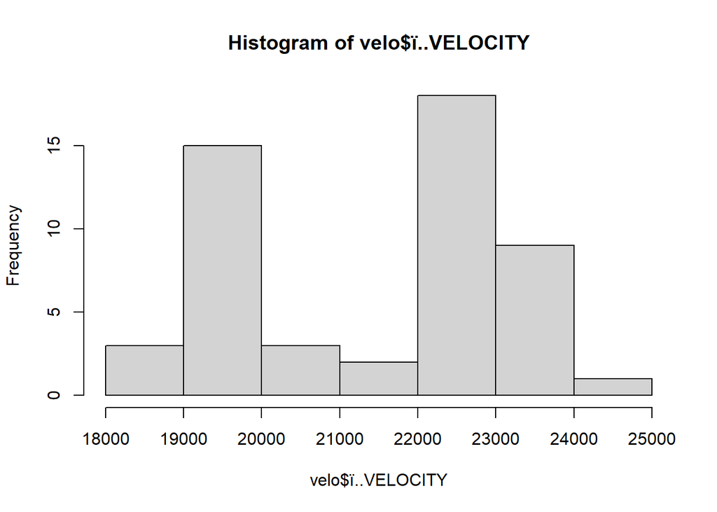

```r
velo <- read.csv("GALAXY2.csv")
hist(velo$ï..VELOCITY)
```

2. Yes, the evidence is that the velocity group together and there are very few velocities that are not with another

```r
mean(velo$ï..VELOCITY)
```

```
## [1] 21448.25
```

```r
sd(velo$ï..VELOCITY)
```

```
## [1] 1764.103
```

4. This galaxy likely belong to cluster A1775A, the slower cluster

# Task 15

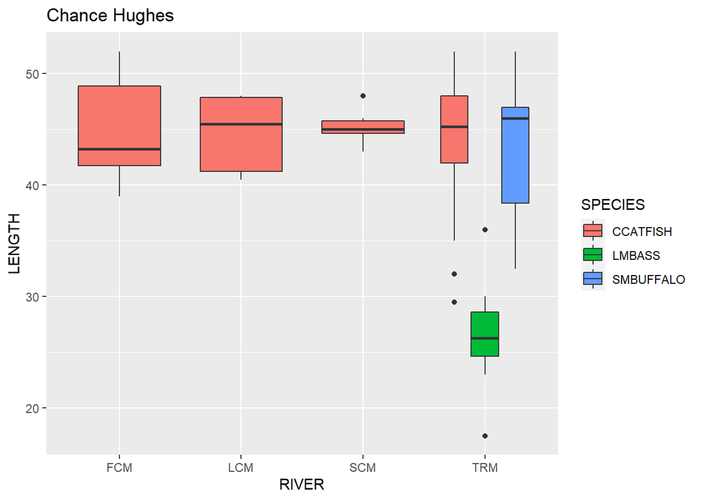

```r
ddt %>% filter(LENGTH < 55, LENGTH > 0, DDT > 0) %>% ggplot(aes(x=RIVER, y=LENGTH, fill=SPECIES)) + geom_boxplot() + ggtitle("Chance Hughes")
```